# MovieLens Recommender Project

### Bias training Method

The bias training method stratifies the data based on the given tags, and calculates the patterns from individual biases. The equation used before regularization is:

$$Y = \mu+b_i+b_u+f(d_{u,i})+\sum_{k+1}^Kx_{u,i}\beta_i+\xi_{u,i}$$

with $f$ a smooth function of $d_{u,i}$, $x_{u,i}^k =1$ if $g_{u,i}$ is genre $k$

The bias training method was a more straight forward approach to generating predictions. Its starts by breaking `edx` data into a `train_set` and a `test_set`.

```r
set.seed(719)
test_index <- createDataPartition(edx$rating, times = 1, p = 0.2, list = FALSE)
test_set <- edx[test_index,]
train_set <- edx[-test_index,]

test_set <- test_set %>%
  semi_join(train_set, by = "movieId") %>%
  semi_join(train_set, by = "userId")
```

The following bias model groups the data by movie, user, genre, and week, and uses regularization and the simple mean to predict a value.

```r
  # mu is naive mean
  mu <- mean(train_set$rating)

  # movie bias
  b_i <- train_set %>%
    group_by(movieId) %>%
    summarize(b_i = sum(rating - mu)/(n()+l))

  # user bias
  b_u <- train_set %>%
    left_join(b_i, by="movieId") %>%
    group_by(userId) %>%
    summarize(b_u = sum(rating - b_i - mu)/(n()+l))

  # genre bias
  b_g <- train_set %>%
    left_join(b_i, by="movieId") %>%
    left_join(b_u, by="userId") %>%
    group_by(genres) %>%
    summarize(b_g = sum(rating - b_u - b_i - mu)/(n()+l))

  # time bias
  b_t <- train_set %>%
    left_join(b_i, by="movieId") %>%
    left_join(b_u, by="userId") %>%
    left_join(b_g, by="genres") %>%
    group_by(date) %>%
    summarize(b_t = sum(rating - b_g - b_u - b_i - mu)/(n()+l))

  # join baises with test set to generate new predictions
  predicted_ratings <- test_set %>%
    left_join(b_i, by = "movieId") %>%
    left_join(b_u, by = "userId") %>%
    left_join(b_g, by = "genres") %>%
    left_join(b_t, by = "date") %>%
    mutate(pred = mu + b_i + b_u + b_g + b_t) %>%
    select(pred)

  RMSE(test_set$rating, predicted_ratings$pred)
```

Using this general model, a for loop can be used to optimize the lambda value to the test set. With the loop. a plot of the lambdas effect on the RMSE based on the number of decimal points shows the how much precision is warranted:

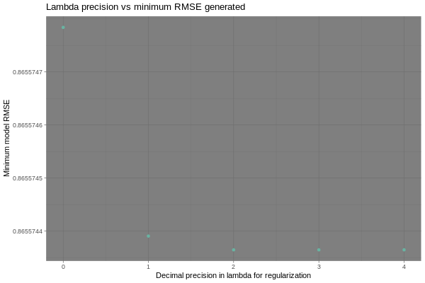

The ideal lambda found by the `for loop` with a seed of $719$ when using `createDataPartition()` is:
$$\lambda = 5.16$$

The same model was then applied to the `validation` set, using the whole of `edx` as a training tool.

## Results

The result from each of the three methods outline in the previous section are as follows:

| Model | RMSES |
| --- | --- |
| Naive Mean Model | 1.061202 |
| SVD Model | 1.032113 |
| Biases Model | 0.864305 |

## Conclusion

In this project, a great deal was learned about the relationships between variables in a relatively simple rating data set, and was eye opening in terms of how complicated recommenders at Spotify or Netflix must be. It also made obvious the need for computing power when working with large datasets.  
Ironically the only model well suited to extrapolate ratings was the naive mean model. An SVD model, or biases model are unable to operate well outside a validation set that contains new users or movies. The biases model might perform slightly better because it can receive genre information, but these methods are really designed to be interpolative, and therefore are not incredibly practical in the real world.  
The biases model has a lot of potential for better bias training. One example, could be to include the fact that ratings are discrete on a $0.5$ star increment, and people are more likely to rate with a rounded whole star than half a star. This could allow a bias to be trained that rounds in a non-traditional way. Another bias could be included that takes into account the change in perception about a movie as the ratings become farther away from a release date. Someone who rates a movie years after the release date might be inclined to rate it better for nostalgic reasons, or the simple fact someone is watching it years later means the movie has aged well (in a general case). Unfortunately, it would be difficult to include many biases because the process of calculation gets much more intensive the more biases one collects. An approach that uses corellations is probably more robust, and one doesn’t need to understand why certain movies or users are linked to use the data to improve the recommendations.

## References

1. https://rstudio-pubs-static.s3.amazonaws.com/100749_6b0f55153e71461fa382fd2a2db66507.html, R markdown tips
2. https://rstudio.github.io/distill/tables.html, help with tables
3. https://rstudio-pubs-static.s3.amazonaws.com/100749_6b0f55153e71461fa382fd2a2db66507.html, R markdown notation
4. https://www.netflixprize.com/index.html, netflix prize information
5. https://www.r-graph-gallery.com/line-chart-dual-Y-axis-ggplot2.html, data visualization help
6. https://rstudio-pubs-static.s3.amazonaws.com/287285_226b14b0d57345cd84219bad6e60c0cd.html, Matrix Factorization & SVD
7. https://rpubs.com/tarashnot/recommender_comparison, recommender project example
8. https://grouplens.org/datasets/movielens, MovieLens data information
9. https://data-flair.training/blogs/data-science-r-movie-recommendation, recommender tutorial